# ADLP: Accident and Development period adjusted Linear Pools

This vignette aims to illustrate how the `ADLP` package can be used to objectively combine multiple stochastic loss reserving models such that the strengths offered by different models can be utilised effectively.

## Set Up

To showcase the `ADLP` package, we will import a test claims dataset from [`SynthETIC`](https://CRAN.R-project.org/package=SynthETIC). Note that some data manipulation is needed to transform the imported object into a compatible format for `ADLP`, however any `data.frame` with column 1 titled “origin” for accident periods and column 2 titled “dev” for development periods will work. All other columns can be constructed as required for model inputs.

```r
library(ADLP)
if (!require(SynthETIC)) install.packages("SynthETIC")
if (!require(tidyverse)) install.packages("tidyverse")
library(tidyverse)

# Import dummy claims dataset
claims_dataset <- claims_dataset <- ADLP::test_claims_dataset

head(claims_dataset)
```

|  | origin | dev | calendar | claims |
| --- | --- | --- | --- | --- |
| 1 | 1 | 1 | 2 | 0.00 |
| 2 | 1 | 2 | 3 | 46985.03 |
| 3 | 1 | 3 | 4 | 392545.85 |
| 4 | 1 | 4 | 5 | 185946.11 |
| 5 | 1 | 5 | 6 | 700630.30 |
| 6 | 1 | 6 | 7 | 261024.51 |

## Training and Validation Split

As the ADLP weightings are determined through testing on a validation set, we need to split the claims dataset into a training, validation and testing set.

```r
# Included train/validation splitting function
train_val <- ADLP::train_val_split_method1(
    df = claims_dataset,
    tri.size = 40,
    val_ratio = 0.3,
    test = TRUE
)

train_data <- train_val$train
valid_data <- train_val$valid
insample_data <- rbind(train_data, valid_data)
test_data <- train_val$test

print("Number of observations in each row")
```

```
#> [1] "Number of observations in each row"
```

```r
print(nrow(train_data))
```

```
#> [1] 575
```

```r
print(nrow(valid_data))
```

```
#> [1] 245
```

```r
print(nrow(test_data))
```

```
#> [1] 780
```

```r
print("Approximation for val_ratio")
```

```
#> [1] "Approximation for val_ratio"
```

```r
print(nrow(valid_data)/(nrow(insample_data)))
```

```
#> [1] 0.2987805
```

## Constructing Components

This example will construct an ADLP with three components. However, any number of base models will also function well.

```r
base_model1 <- glm(formula = claims~factor(dev),
                   family=gaussian(link = "identity"), data=train_data)

tau <- 1e-8
base_model2 <- glm(formula = (claims+tau)~calendar,
                   family=Gamma(link="inverse"), data=train_data)

base_model3 <- glm(formula = claims~factor(origin),
                   family=gaussian(link = "identity"), data=train_data)

base_model1_full <- update(base_model1, data = insample_data)
base_model2_full <- update(base_model2, data = insample_data)
base_model3_full <- update(base_model3, data = insample_data)
```

To also support desired outputs including densities and predictions, the base components will also require `calc_dens`, `calc_mu`, `calc_cdf` and `sim_fun` methods to be defined for each base component. See `?adlp_component` for more information.

```r
################################################################################
# Normal distribution densities and functions
dens_normal <- function(y, model, newdata){
    pred_model <- predict(model, newdata=newdata, type="response", se.fit=TRUE)
    mu <- pred_model$fit
    sigma <- pred_model$residual.scale
    return(dnorm(x=y, mean=mu, sd=sigma))
}

cdf_normal<-function(y, model, newdata){
    pred_model <- predict(model, newdata=newdata, type="response", se.fit=TRUE)
    mu <- pred_model$fit
    sigma <- pred_model$residual.scale
    return(pnorm(q=y, mean=mu, sd=sigma))
}

mu_normal<-function(model, newdata){
    mu <- predict(model, newdata=newdata, type="response")
    mu <- pmax(mu, 0)
    return(mu)
}

sim_normal<-function(model, newdata){
    pred_model <- predict(model, newdata=newdata, type="response", se.fit=TRUE)
    mu <- pred_model$fit
    sigma <- pred_model$residual.scale

    sim <- rnorm(length(mu), mean=mu, sd=sigma)
    sim <- pmax(sim, 0)
    return(sim)
}

################################################################################
# Gamma distribution densities and functions
dens_gamma <- function(y, model, newdata){
    pred_model <- predict(model, newdata=newdata, type="response", se.fit=TRUE)
    mu <- pred_model$fit
    sigma <- pred_model$residual.scale
    return(dgamma(x=y, shape = 1/sigma, scale=(mu*sigma)^2))
}

cdf_gamma <- function(y, model, newdata){
    pred_model <- predict(model, newdata=newdata, type="response", se.fit=TRUE)
    mu <- pred_model$fit
    sigma <- pred_model$residual.scale
    return(pgamma(q=y, shape = 1/sigma, scale=(mu*sigma)^2))
}

mu_gamma <- function(model, newdata, tau){
    mu <- predict(model, newdata=newdata, type="response")
    mu <- pmax(mu - tau, 0)
    return(mu)
}

sim_gamma <- function(model, newdata, tau){
    pred_model <- predict(model, newdata=newdata, type="response", se.fit=TRUE)
    mu <- pred_model$fit
    sigma <- pred_model$residual.scale

    sim <- rgamma(length(mu), shape = 1/sigma, scale=(mu*sigma)^2)
    sim <- pmax(sim - tau, 0)
    return(sim)
}
```

## Fitting ADLPs

The different user defined base models are then structured as a `adlp_component` object to be used in model fitting for `adlp`.

```r
# Constructing ADLP component classes

base_component1 = adlp_component(
    model_train = base_model1,
    model_full = base_model1_full,
    calc_dens = dens_normal,
    calc_cdf = cdf_normal,
    calc_mu = mu_normal,
    sim_fun = sim_normal
)

base_component2 = adlp_component(
    model_train = base_model2,
    model_full = base_model2_full,
    calc_dens = dens_gamma,
    calc_cdf = cdf_gamma,
    calc_mu = mu_gamma,
    sim_fun = sim_gamma,
    tau = tau
)

base_component3 = adlp_component(
    model_train = base_model3,
    model_full = base_model3_full,
    calc_dens = dens_normal,
    calc_cdf = cdf_normal,
    calc_mu = mu_normal,
    sim_fun = sim_normal
)

components <- adlp_components(
    base1 = base_component1,
    base2 = base_component2,
    base3 = base_component3
)
```

`adlp` objects are fitted using the validation data to determine the best weighting to choose for each partition.

Note that different partitions can be used. `fit1` uses no partition, meaning that the weights are determined via standard linear pooling. `fit2` is an example of creating 3 partitions in the validation data, with the accident periods being chosen to optimise the desired weighting of each partition.

```r
# Fitting ADLP class
fit1 <- adlp(
    components_lst = components,
    newdata = valid_data,
    partition_func = ADLP::adlp_partition_none
)

fit2 <- adlp(
    components_lst = components,
    newdata = valid_data,
    partition_func = ADLP::adlp_partition_ap,
    tri.size = 40,
    size = 3,
    weights = c(3, 1, 2)
)


fit1
```

```
#> [1] "ADLP Components:"
#> [1] "base1" "base2" "base3"
#> [1] "ADLP weights:"
#> [[1]]
#>     base1     base2     base3
#> 0.7853159 0.0000000 0.2146841
```

```r
fit2
```

```
#> [1] "ADLP Components:"
#> [1] "base1" "base2" "base3"
#> [1] "ADLP weights:"
#> [[1]]
#>     base1     base2     base3
#> 0.7838638 0.0000000 0.2161362
#>
#> [[2]]
#>     base1     base2     base3
#> 0.5237283 0.0000000 0.4762717
#>
#> [[3]]
#>     base1     base2     base3
#> 0.7853159 0.0000000 0.2146841
```

## Supported Outputs

The `ADLP` package supports calculation of log score, CRPS, prediction and simulation from each of the ensemble models. Note that the user-defined functions for each of the component models is necessary to perform this calculation.

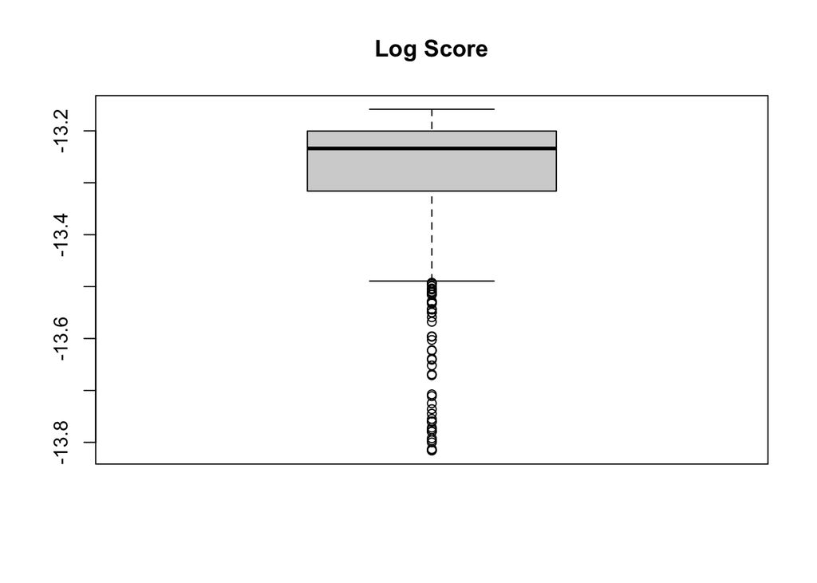

```r
# Log Score
ensemble_logS <- adlp_logS(fit1, test_data, model = "full")

# Cumulative Ranked Probability Score
ensemble_CRPS <- adlp_CRPS(fit1, test_data, response_name = "claims", model = "full", sample_n = 1000)

# Predictions
ensemble_means <- predict(fit1, test_data)

# Simulations
ensemble_simulate <- adlp_simulate(100, fit1, test_data)

boxplot(ensemble_logS$dens_val, main = "Log Score")
```

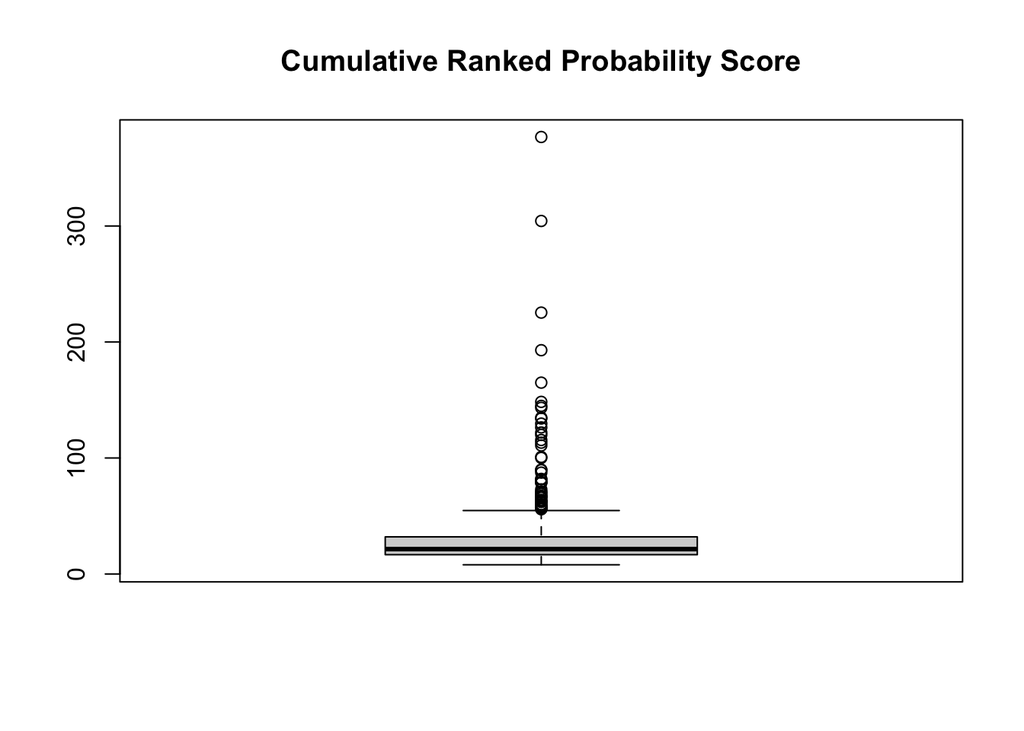

```r
boxplot(ensemble_CRPS$ensemble_crps, main = "Cumulative Ranked Probability Score")
```

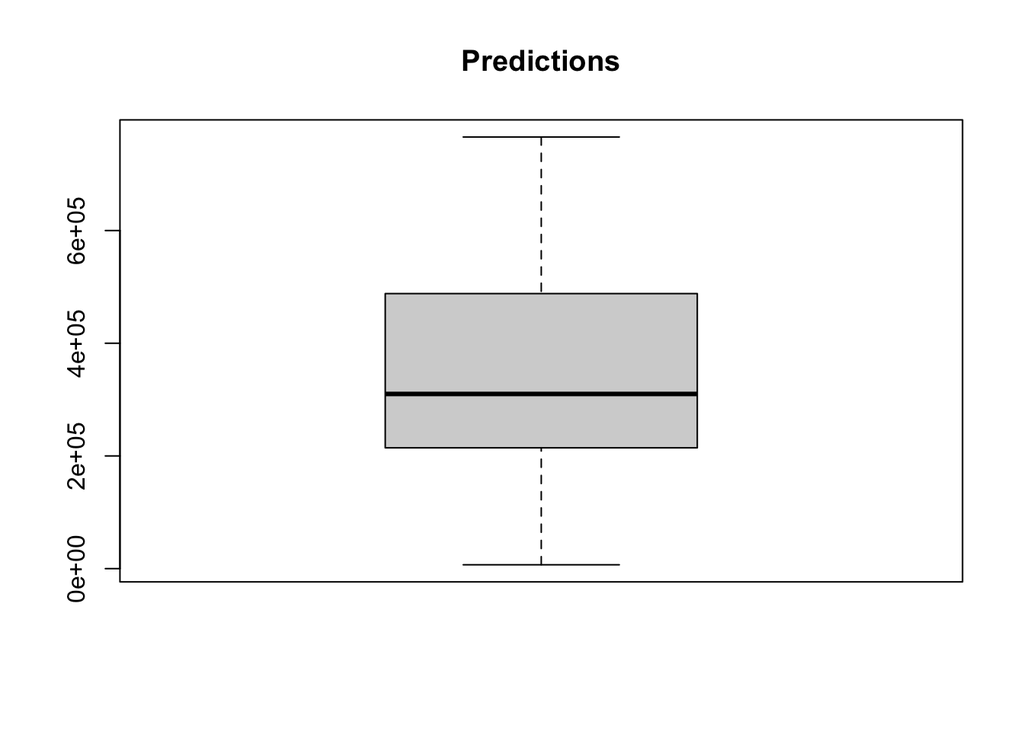

```r
boxplot(ensemble_means$ensemble_mu, main = "Predictions")
```

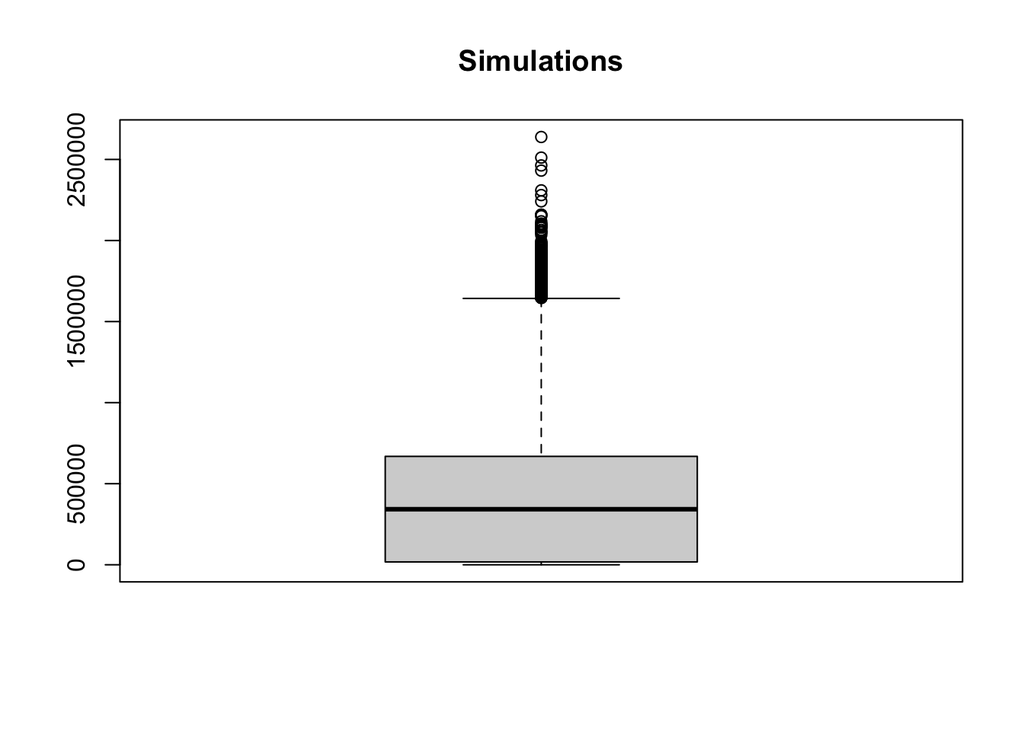

```r
boxplot(ensemble_simulate$simulation, main = "Simulations")
```

## Different partition

The sample below shows how a user can define their own partition function to be used within model fitting.

```r
# Defining own partition function
user_defined_partition <- function(df) {
    return (list(
        subset1 = df[(as.numeric(as.character(df$origin)) >= 1) & (as.numeric(as.character(df$origin)) <= 15), ],
        subset2 = df[(as.numeric(as.character(df$origin)) >= 16) & (as.numeric(as.character(df$origin)) <= 40), ]
    ))
}

# Fitting ADLP class
fit3 <- adlp(
    components_lst = components,
    newdata = valid_data,
    partition_func = user_defined_partition
)

fit3
```

```
#> [1] "ADLP Components:"
#> [1] "base1" "base2" "base3"
#> [1] "ADLP weights:"
#> [[1]]
#>     base1     base2     base3
#> 0.6472695 0.0000000 0.3527305
#>
#> [[2]]
#>     base1     base2     base3
#> 0.7853159 0.0000000 0.2146841
```

## Comparing models through MSE

Note that this may also be due to model variance and we have not chosen to optimise the base models.

```r
show_mse <- function(data) {
    print("----------------------------")
    print("Base models 1, 2, 3")
    print(sum((predict(base_model1_full, data, type = "response") - data$claims)^2))
    print(sum((predict(base_model2_full, data, type = "response") - data$claims)^2))
    print(sum((predict(base_model3_full, data, type = "response") - data$claims)^2))

    print("ADLP ensembles 1, 2, 3")
    print(sum((predict(fit1, data)$ensemble_mu - data$claims)^2))
    print(sum((predict(fit2, data)$ensemble_mu - data$claims)^2))
    print(sum((predict(fit3, data)$ensemble_mu - data$claims)^2))
    print("----------------------------")
}

show_mse(train_data)
```

```
#> [1] "----------------------------"
#> [1] "Base models 1, 2, 3"
#> [1] 9.148445e+13
#> [1] 1.212692e+14
#> [1] 1.156972e+14
#> [1] "ADLP ensembles 1, 2, 3"
#> [1] 9.043105e+13
#> [1] 9.043557e+13
#> [1] 9.056253e+13
#> [1] "----------------------------"
```

```r
show_mse(valid_data)
```

```
#> [1] "----------------------------"
#> [1] "Base models 1, 2, 3"
#> [1] 4.634486e+13
#> [1] 5.964421e+13
#> [1] 5.31757e+13
#> [1] "ADLP ensembles 1, 2, 3"
#> [1] 4.610282e+13
#> [1] 4.610436e+13
#> [1] 4.640151e+13
#> [1] "----------------------------"
```

```r
show_mse(test_data)
```

```
#> [1] "----------------------------"
#> [1] "Base models 1, 2, 3"
#> [1] 1.00074e+14
#> [1] 1.359745e+14
#> [1] 1.804106e+14
#> [1] "ADLP ensembles 1, 2, 3"
#> [1] 1.028518e+14
#> [1] 1.028976e+14
#> [1] 1.030806e+14
#> [1] "----------------------------"
```